# Final_model

## Table of Contents:

1.BROADBAND OUTAGE DETECTION ANALYSIS

2.Project Objectives

3.Problem Statement

4.Model Flowchart

5.Introduction to dataset:

6.Import the library

7.Loading the datasets

8.Basic Data Understanding

8.1. Train and Test Data Understanding

8.2. Beneficiary Data Understanding

9.Exploratory Data Analysis

9.1 Univariate Data Analysis - Exploring univariate variables (Area, Server type, Log Report, Volume, Broadband type and Outage type

9.2 Questions from operations team

9.3 Data Merging

9.2 Bivariate Analysis - Relation between Volume and Outage type

10. Data Preprocessing

10.1 Merging the train and test file with server type, log report type,boradband type

10.2 Splitting merged train data into training and testing set(0.3)

10.3 Checking data types and seperating categorical and float features

11.Model building One iteration

11.1 Bulding classification models using Logistic,Descision tree,Random forest and XGboost

11.2 Evaluating accuracy , f1scores - micro ,macro and weighted on training and testing set

12.Feature engineering

12.1 Append Train to Test to derive more accurate features

12.2 create new feature with combined file

13.Data Preprocessing

13.1 Type Conversion

13.2 Dummification

14.Model building Multiple iterations for different setof features

14.1 Build model with all the features - Random Forest

14.2 Build model with all the features - logistic Regression

14.3 Build model with all the features - XGBoost

14.4 Verify F1 macro score on splitted test data

14.5 Analyzing feature importance and building model for different set of features

14.4 Finalizing cutoff value for feature importance on test data

15.Retraining the mutiple iteration with selected features and hyperparameter tuning

15.1 Checking f1-macro with retrained model

16.Conclusion

16.1 Important Features

16.2 Model Performance

16.3 Model Improvement

# BROADBAND OUTAGE DETECTION ANALYSIS

# Project Objectives

Broadband outage problem is one of the biggest problems now days. As we know that Broadband Operatores strive to provide the best possible service to customers and broadband outages are taken very seriously as they effect user experience and also impact the Business revenue.

# Problem Statement

# Model Flowchart

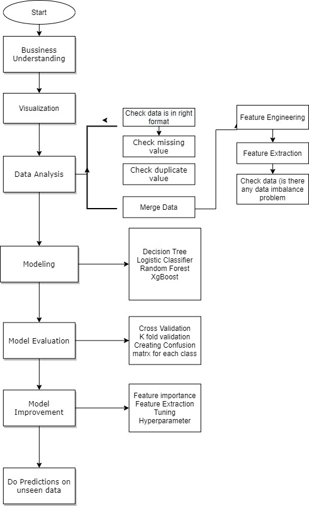

# Introduction to the Dataset

For the purpose of this project, we are considering There are 5 CSV files provided to us, they are described below:

**A) Train Data**

This data provides insights about unique event `id` for each observation of the `outage_duration` in a particular `area_code`

**B) Broadband Data**

This data provides details about the 10 different types of broadbands.

**C) Outage Data**

There are 5 different outage_type recorded in the dataset.

**D) Report Data**

This data contains log_report_type is a type of the recorded report generated by a technical team member after evaluating the outage. volume is the volume of data handled in the area at the time of report in custom company specific units

**E) Server Data**

This data contains the record of the`transit_server_type` that is stored in the dataset. Transit Servers handle the requests and responses of the customers.

# Importing required packages

```python
import numpy as np
import pandas as pd
import matplotlib.pyplot as plt
import matplotlib
import seaborn as sns
import scipy.stats as sct
import pylab
%matplotlib inline
```

# Loading the datasets

```python
# Load Train Dataset
import os
os.chdir("C:/Users/Gunjan/Downloads/20200628_CSE9099c_PHD_Dataset-1593175193570/data")
train = pd.read_csv("train_data.csv")
train_broadband_data = pd.read_csv("broadband_data.csv")
train_outage_data = pd.read_csv("outage_data.csv")
train_report_data = pd.read_csv("report_data.csv")
train_server_data = pd.read_csv("server_data.csv")
test = pd.read_csv("test_data.csv")
```

```python
## Lets Check Shape of datasets

print('Shape of train data :',train.shape)
print('Shape of train_broadband data :',train_broadband_data.shape)
print('Shape of train_outage data :',train_outage_data.shape)
print('Shape of train_report data :',train_report_data.shape)
print('Shape of train_server data :',train_server_data.shape)
print('Shape of test data :',test.shape)
```

```
Shape of train data : (5904, 3)
Shape of train_broadband data : (21076, 2)
Shape of train_outage data : (18552, 2)
Shape of train_report data : (58671, 3)
Shape of train_server data : (31170, 2)
Shape of test data : (1477, 2)
```

## Basic Data Understanding

### Train and Test Data Understanding

```python
## Lets check shape of Train and Test Data

print('train Sample:\n',train.head(2),'\n')
print('broadband Sample:\n', train_broadband_data.head(2), '\n')
print('outage Sample:\n', train_outage_data.head(2), '\n')
print('report Sample:\n', train_report_data.head(2), '\n')
print('server Sample:\n', train_server_data.head(2), '\n')
print('\n test Shape:',test.shape,'\n')
print('test Sample: \n',test.head(2))
```

```
train Sample:
       id area_code  outage_duration
0  13366  area_415                1
1   6783  area_474                0

broadband Sample:
      id    broadband_type
0  6597  broadband_type_8
1  8011  broadband_type_8

outage Sample:
      id    outage_type
0  6597  outage_type_2
1  8011  outage_type_2

report Sample:
      id     log_report_type  volume
0  6597  log_report_type_68       6
1  8011  log_report_type_68       7

server Sample:
      id     transit_server_type
0  6597  transit_server_type_11
1  8011  transit_server_type_15


 test Shape: (1477, 2)

test Sample:
       id area_code
0   3340  area_344
1  14067  area_933
```

### Beneficiary Data Understanding

```python
## Lets check the missing value in data
print('\n Total missing values in train :',train.isna().sum().sum())
print('\n Total missing values in broadband :',train_broadband_data.isna().sum().sum())
print('\n Total missing values in outage :',train_outage_data.isna().sum().sum())
print('\n Total missing values in report :',train_report_data.isna().sum().sum())
print('\n Total missing values in server :',train_server_data.isna().sum().sum())
print('\n Total missing values in test :',test.isna().sum().sum())
```

```
 Total missing values in train : 0

 Total missing values in broadband : 0

 Total missing values in outage : 0

 Total missing values in report : 0

 Total missing values in server : 0

 Total missing values in test : 0
```

# Exploratory Data Analysis

## Univariate Data Analysis - Exploring univariate variables (Area, Server type, Log Report, Volume, Broadband type and Outage type]

## Distribution of outage duration in the train data

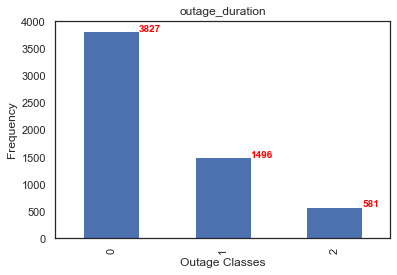

```python
from matplotlib.pylab import rcParams
rcParams['figure.figsize'] = 20, 7
%matplotlib inline
bplot_outage = train.outage_duration.value_counts().plot(kind= 'bar')
bplot_outage.set_title("outage_duration")
bplot_outage.set_xlabel("Outage Classes")
bplot_outage.set_ylabel("Frequency")
for i, v in enumerate(train.outage_duration.value_counts()):
    bplot_outage.text(i + 0.25 , v ,str(v), color='red', fontweight='bold')
```

*** **Key Insight** - It's obvious from outage classes that samples with no outage are extremely high that one with outage, Frequency also decreases as outage classes increases. It also gives us an indication that target has class imbalance.

## Distribution of Broadband Type in the train data

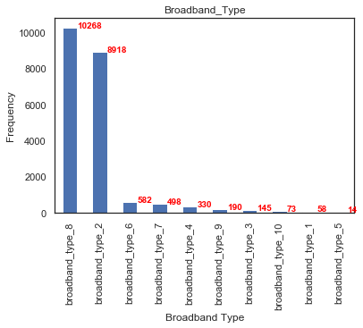

```python
from matplotlib.pylab import rcParams
rcParams['figure.figsize'] = 25, 10
%matplotlib inline
bplot_broadband = train_broadband_data.broadband_type.value_counts().plot(kind= 'bar')
bplot_broadband.set_title("Broadband_Type")
bplot_broadband.set_xlabel("Broadband Type")
bplot_broadband.set_ylabel("Frequency")
for i, v in enumerate(train_broadband_data.broadband_type.value_counts()):
    bplot_broadband.text(i + 0.25 , v ,str(v), color='red', fontweight='bold')
```

*** **Key Insight** -

Broadband type 8 has the highest frequency distribution followed by resource type 2. "ADSL 1" and "ADSL 2" may be most used braodband types and could be most error prone.

## Distribution of Outage type in the train data

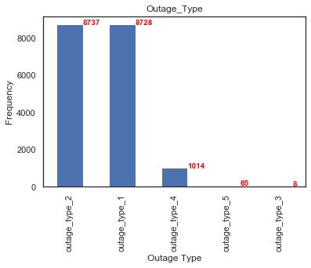

```python
from matplotlib.pylab import rcParams
matplotlib.rcParams['figure.figsize'] = (20.0, 10.0)
%matplotlib inline
bplot_Outage_Type = train_outage_data.outage_type.value_counts().plot(kind= 'bar')
bplot_Outage_Type.set_title("Outage_Type")
bplot_Outage_Type.set_xlabel("Outage Type")
bplot_Outage_Type.set_ylabel("Frequency")
for i, v in enumerate(train_outage_data.outage_type.value_counts()):
    bplot_Outage_Type.text(i + 0.25 , v ,str(v), color='red', fontweight='bold')
```

*** **Key Insight** - Outage type 2 and Outage type 1 have extremely large distribution than other. We can consider binning these variables to decreases the skewness.

## Distribution of Server type in the train data

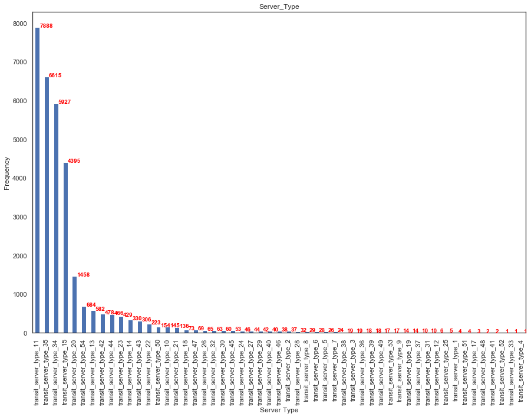

```python
from matplotlib.pylab import rcParams
#rcParams['figure.figsize'] = 50,50
#matplotlib.rcParams['figure.figsize'] = (40.0, 20.0)
#%matplotlib inline
bplot_server = train_server_data.transit_server_type.value_counts().plot(kind= 'bar' , figsize= (15.0, 10.0))
bplot_server.set_title("Server_Type")
bplot_server.set_xlabel("Server Type")
bplot_server.set_ylabel("Frequency")
for i, v in enumerate(train_server_data.transit_server_type.value_counts()):
    bplot_server.text(i + 0.25 , v ,str(v), color='red', fontweight='bold')
```

***Key Insight - Apart from Type 11,35,34,15 other server types have fairly low frequency distribution and we can bin them into different categories. 11,35 -High 34,15, 20 - Medium and others in Low.

## Questions from operations team-

1. Which areas are most prone to long outage durations?
2. Which broadband types are suspect of long outage durations?
3. Any other recommendations to improve the detection of outage durations.

We will analyze and try to answer these questions by exploring training data sets.

**Exploring area and outages from train.csv**

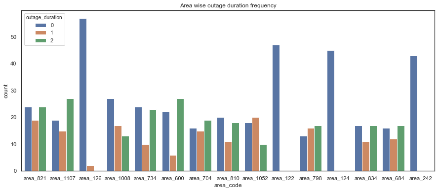

```python
sns.set(rc={'figure.figsize':(15,6)},style='white')

ax=sns.countplot(x='area_code',hue='outage_duration',data=train
              ,order=train.area_code.value_counts().iloc[:15].index)

plt.title('Area wise outage duration frequency')

plt.show()
```

***key insight - Our data has many areas with 0 outages.

**Estimating total outage duration time assuming outage category 1 is for 1 hour and 2 is for more than two hours duration**

```python
#calculating total outage duration , grouping with area_code
highest_outage_hours = train.loc[:, train_report_data.columns != 'id']
highest_outage_hours = highest_outage_hours.groupby('area_code',as_index = True , sort = True).sum()
highest_outage_hours = highest_outage_hours.sort_values(by = ['outage_duration'], ascending=[False])
highest_outage_hours[:10]
```

| area_code | outage_duration |
| --- | --- |
| area_1107 | 69 |
| area_821 | 67 |
| area_1100 | 62 |
| area_600 | 60 |
| area_734 | 56 |
| area_704 | 53 |
| area_798 | 50 |
| area_810 | 47 |
| area_684 | 46 |
| area_995 | 45 |

**Exploring area wise total outages duration from train.csv**

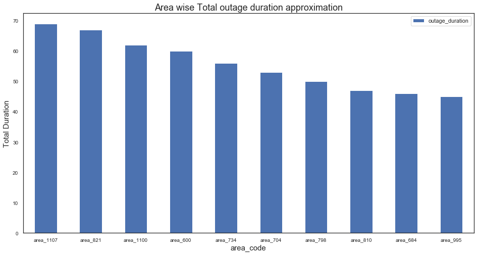

```python
sns.set(rc={'figure.figsize':(50,40)},style='white')
highest_outage_hours[:10].plot(kind = 'bar', rot=0,figsize=(16,8),fontsize=10)
plt.title("Area wise Total outage duration approximation",fontsize=18)
plt.xlabel("area_code",fontsize=15)
plt.ylabel("Total Duration",fontsize=15)
plt.show()
```

***key insight - Areas 1107,821,1100 and 600 have faced more hour outages duration.

```python
#to answer first question about the areas most prone with long duration outage
```

```python
#long outage areas
outage_duration_2 = train[train['outage_duration'] == 2].groupby('area_code', sort = True ).count()
#medium outage areas
outage_duration_1 = train[train['outage_duration'] == 1].groupby('area_code', sort = True ).count()
#No outage areas
outage_duration_0 = train[train['outage_duration'] == 0].groupby('area_code', sort = True ).count()
#creating cross tab to understand counts for each outage duration category
pd.crosstab(train.area_code , train.outage_duration).sort_values(2, ascending = False)
```

| outage_duration area_code | 0 | 1 | 2 |
| --- | --- | --- | --- |
| area_1100 | 2 | 6 | 28 |
| area_1107 | 19 | 15 | 27 |
| area_600 | 22 | 6 | 27 |
| area_821 | 24 | 19 | 24 |
| area_734 | 24 | 10 | 23 |
| ... | ... | ... | ... |
| area_403 | 1 | 2 | 0 |
| area_404 | 0 | 3 | 0 |
| area_405 | 2 | 1 | 0 |
| area_406 | 0 | 3 | 0 |
| area_999 | 2 | 3 | 0 |

876 rows × 3 columns

**Exploring area most prone with long duration outage from train.csv**

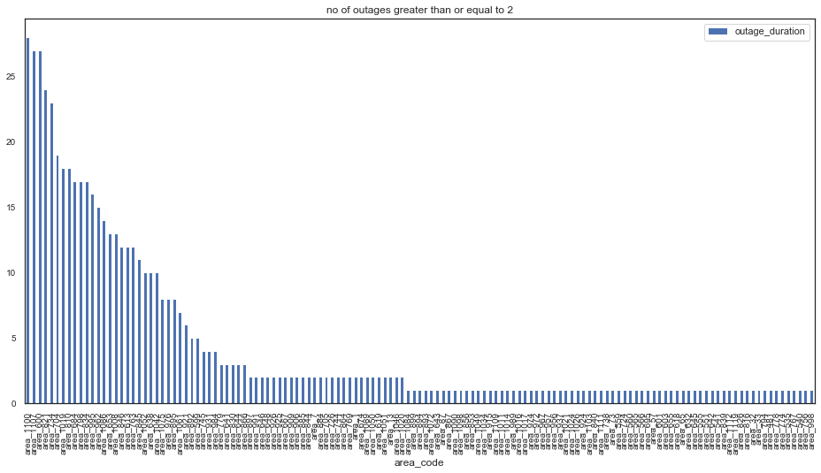

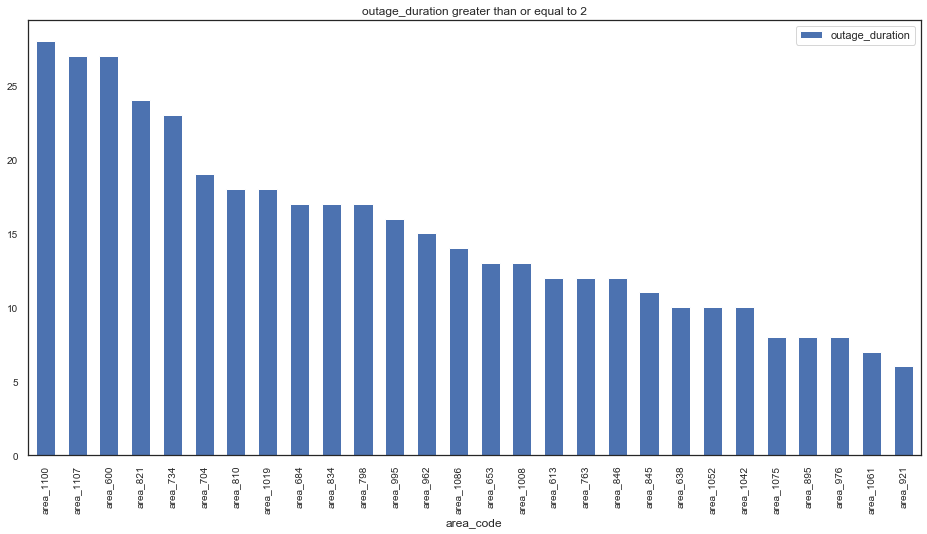

```python
#sns.set(rc={'figure.figsize':(15,10)},style='white')
fig = plt.figure(figsize=(20,15))
outage_duration_2.sort_values("outage_duration", ascending= False).plot( kind = 'bar', title="no of outages greater than or equal to 2", y = "outage_duration",
                       align = 'center',  width=0.6 , figsize=(16,8),fontsize=10 )
outage_duration_2[outage_duration_2.outage_duration > 5].sort_values("outage_duration", ascending= False).plot( kind = 'bar', title="outage_duration greater than or equal to 2",
                                                            y = "outage_duration",align = 'center',  width=0.6,figsize=(16,8),fontsize=10  )
```

***key insight -

areas 1100, 1107, 600 and 821 most prone with long duration outage

# Data Merging

```python
#  Merge Train and Broadband type data and create merge_1 dataset.
merge_1 = train.merge(train_broadband_data, how = 'inner', left_on='id', right_on='id')
merge_1.shape
```

```
(6754, 4)
```

```python
#creating cross tab to understand counts for each broadband type
pd.crosstab(merge_1.broadband_type, merge_1.outage_duration, margins = True, margins_name = "Total" )
```

| outage_duration broadband_type | 0 | 1 | 2 | Total |
| --- | --- | --- | --- | --- |
| broadband_type_1 | 7 | 10 | 10 | 27 |
| broadband_type_10 | 19 | 8 | 1 | 28 |
| broadband_type_2 | 2242 | 527 | 82 | 2851 |
| broadband_type_3 | 17 | 23 | 4 | 44 |
| broadband_type_4 | 56 | 41 | 17 | 114 |
| broadband_type_5 | 0 | 0 | 3 | 3 |
| broadband_type_6 | 63 | 112 | 26 | 201 |
| broadband_type_7 | 93 | 77 | 9 | 179 |
| broadband_type_8 | 1683 | 1019 | 544 | 3246 |
| broadband_type_9 | 34 | 23 | 4 | 61 |
| Total | 4214 | 1840 | 700 | 6754 |

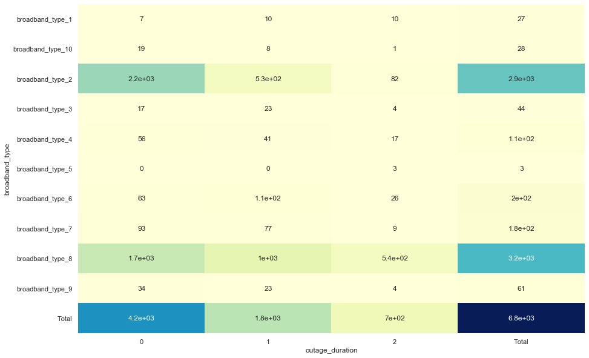

```python
#calculating broadband_type with most no of outage duration
sns.set(rc={'figure.figsize':(15,10)},style='white')
sns.heatmap(pd.crosstab(merge_1.broadband_type, merge_1.outage_duration, margins = True,
                        margins_name = "Total" ), cmap="YlGnBu", annot = True, cbar= False)
```

***key insight -

broadband_type_2 and broadband_type_8 has most no of outage

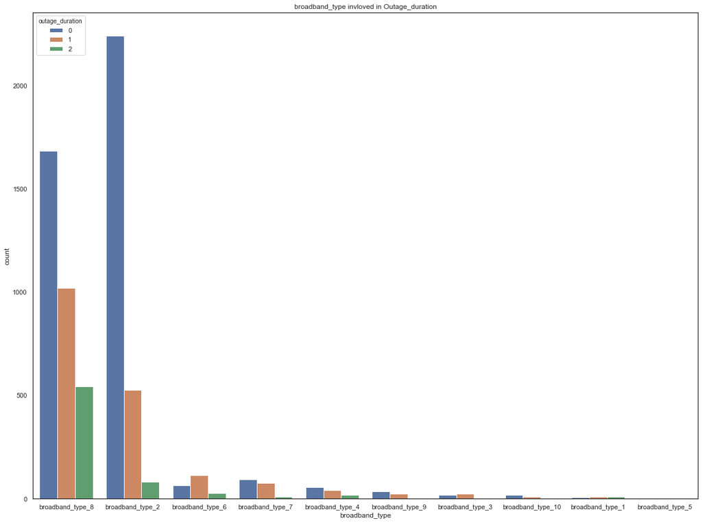

```python
## Lets plot countplot for each Broadband_type categories

sns.set(rc={'figure.figsize':(20,15)},style='white')

ax=sns.countplot(x='broadband_type',hue='outage_duration',data=merge_1
              ,order=merge_1.broadband_type.value_counts().iloc[:10].index)

plt.title('broadband_type invloved in Outage_duration')

plt.show()

plt.savefig('In broadband outage duration')
```

***key insight -

broadband_type_8 has long outage durations

```python
# Merge_1(Train and Broadband) and server type data and create merge_2 dataset.
merge_2 = merge_1.merge(train_server_data, how = 'inner', left_on='id', right_on='id')
```

```python
#creating cross tab to understand counts for each transit_server_type
server_outage = pd.crosstab(merge_2.transit_server_type, merge_2.outage_duration)
server_outage=server_outage.sort_values(2, ascending=False, )
server_outage.head()
```

| outage_duration transit_server_type | 0 | 1 | 2 |
| --- | --- | --- | --- |
| transit_server_type_15 | 651 | 386 | 454 |
| transit_server_type_11 | 1693 | 1108 | 427 |
| transit_server_type_13 | 150 | 234 | 78 |
| transit_server_type_20 | 393 | 147 | 61 |
| transit_server_type_54 | 138 | 140 | 60 |

***key insight -

transit_server_type 15, 11, and 13 have long outage durations

```python
# Merge_2(Train, Broadband and server) and report data and create merge_3 dataset.
merge_3= merge_2.merge(train_report_data, how = 'inner', left_on='id', right_on='id')
merge_4= merge_3.merge(train_outage_data, how = 'inner', left_on='id', right_on='id')
merge_4.head(1)
```

|  | id | area_code | outage_duration | broadband_type | transit_server_type | log_report_type | volume | outage_type |
| --- | --- | --- | --- | --- | --- | --- | --- | --- |
| 0 | 13366 | area_415 | 1 | broadband_type_2 | transit_server_type_35 | log_report_type_312 | 1 | outage_type_4 |

```python
#calculating total server_volume using group function with Volume
server_volume = merge_4.groupby('transit_server_type' , as_index = False)['volume'].sum()
server_volume = server_volume.sort_values('volume', ascending=False)
server_volume.head()
```

|  | transit_server_type | volume |
| --- | --- | --- |
| 25 | transit_server_type_35 | 97789 |
| 24 | transit_server_type_34 | 97115 |
| 2 | transit_server_type_11 | 78239 |
| 6 | transit_server_type_15 | 52170 |
| 4 | transit_server_type_13 | 9234 |

***key insight -

transit_server_type 35, 34, 11 and 15 having large volume compares to other Server

## Analysis of Transit Server type wrt to Volume

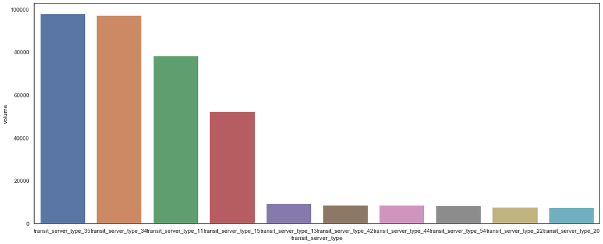

```python
sns.set(rc={'figure.figsize':(20,8)},style='white')
sns.barplot(x = 'transit_server_type', y = 'volume', data = server_volume[:10])
```

***key insight -

transit_server_type 35, 34, 11 and 15 having large volume compares to other Server

```python
#calculating total area_code using groupby function with Volume
area_server = merge_4.groupby('area_code' , as_index = False)['volume'].sum()
area_server = area_server.sort_values('volume', ascending=False)
area_server.shape
```

```
(876, 2)
```

# Bivariate Analysis - Relation between Volume and Outage type

## Analysis of Area Volume wrt to long Outage Duration

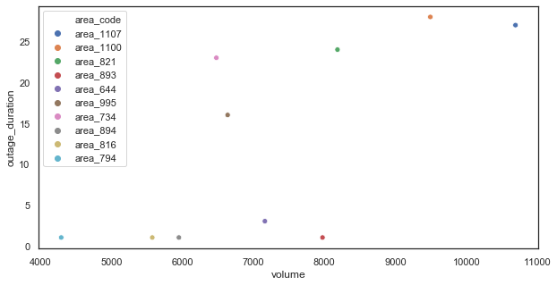

```python
rcParams['figure.figsize'] = 10, 5
merge_5 = area_server.merge(outage_duration_2, how = 'inner', left_on='area_code',
                            right_on='area_code').sort_values('volume',ascending=False)
g = sns.scatterplot(x="volume", y="outage_duration", hue ='area_code' ,data=merge_5[:10] , legend='full')
```

***key insight -

1. Area 821 although handles slightly more data than area 893, but it has much higher long outage duration outages.
2. In genral (barring some exceptions)areas which handle more data than 8 k have higher outages.

Further exploration -

1. Features for reports from high outages areas can be explained.

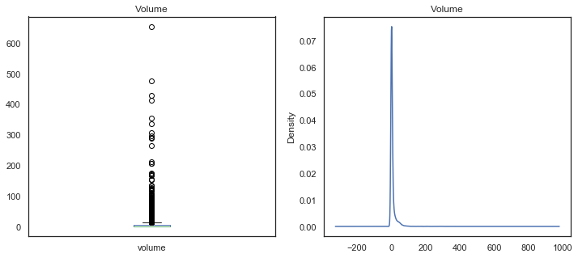

```python
fig,ax = plt.subplots(nrows = 1, ncols = 2)

train_report_data.volume.loc[train_report_data.index.isin(train.id)].plot(kind = 'box',figsize = [12.0,5.0],title="Volume",ax = ax[0])

train_report_data.volume.loc[train_report_data.index.isin(train.id)].plot(kind = 'density',figsize = [12.0,5.0],title="Volume",ax = ax[1])
```

***key insight - Volume is heavily right skewed and hence we can transform the variable to reduce skewness.

## Data Preprocessing

#### Assign outage duration as NA to test data

```python
#remove spaces in area_code string
test['outage_duration'] = 'NA'
test.loc[:,'area_code'] = test['area_code'].apply(lambda x:x.replace(" ",""))
print(test.shape)
print(test.head())
```

```
(1477, 3)
      id area_code outage_duration
0   3340  area_344              NA
1  14067  area_933              NA
2   1134   area_16              NA
3     27  area_793              NA
4   9793  area_344              NA
```

#### creating a cross tab which will have all the transit_server_type categories as columns

#### it will also have the respective frequency for each category with respect to id

#### it will give one row per id and hence it can be merged with our train data. It will ensure one row per id

```python
serv_ct = pd.crosstab(train_server_data.id ,train_server_data.transit_server_type)
print(serv_ct.shape)
serv_ct.head(5)
# crosstab function builds a cross-tabulation table that can show the frequency with which certain groups of data appear
```

```
(18552, 53)
```

| transit_server_type id | transit_server_type_1 | transit_server_type_10 | transit_server_type_11 | transit_server_type_12 | transit_server_type_13 | transit_server_type_14 | transit_server_type_15 | transit_server_type_17 | transit_server_type_18 | transit_server_type_19 | ... | transit_server_type_5 | transit_server_type_50 | transit_server_type_51 | transit_server_type_52 | transit_server_type_53 | transit_server_type_54 | transit_server_type_6 | transit_server_type_7 | transit_server_type_8 | transit_server_type_9 |
| --- | --- | --- | --- | --- | --- | --- | --- | --- | --- | --- | --- | --- | --- | --- | --- | --- | --- | --- | --- | --- | --- |
| 1 | 0 | 0 | 1 | 0 | 1 | 0 | 0 | 0 | 0 | 0 | ... | 0 | 0 | 0 | 0 | 0 | 0 | 0 | 0 | 0 | 0 |
| 2 | 0 | 0 | 0 | 0 | 0 | 0 | 0 | 0 | 0 | 0 | ... | 0 | 0 | 0 | 0 | 0 | 0 | 0 | 0 | 0 | 0 |
| 3 | 0 | 0 | 1 | 0 | 0 | 0 | 0 | 0 | 0 | 0 | ... | 0 | 0 | 0 | 0 | 0 | 0 | 0 | 0 | 0 | 0 |
| 4 | 0 | 0 | 0 | 0 | 0 | 0 | 0 | 0 | 0 | 0 | ... | 0 | 0 | 0 | 0 | 0 | 0 | 0 | 0 | 0 | 0 |
| 5 | 0 | 0 | 0 | 0 | 0 | 0 | 0 | 0 | 0 | 0 | ... | 0 | 0 | 0 | 0 | 0 | 0 | 0 | 0 | 0 | 0 |

5 rows × 53 columns

## Merging the train and test file with server type, log report type, boradband type, outage type

```python
#merging train data with serv_ct on id , merge type was selected as inner join to hold only common rows in resultant set.

merged_train = pd.merge(train, serv_ct, how='inner', on="id", left_on=None, right_on=None,
         left_index=False, right_index=False, sort=True,
         suffixes=('_x', '_y'), copy=True, indicator=False,
         validate=None)

#merging test data with serv_ct on id , merge type was selected as inner join to hold only common rows in resultant set.

merged_test = pd.merge(test, serv_ct, how='inner', on="id", left_on=None, right_on=None,
         left_index=False, right_index=False, sort=True,
         suffixes=('_x', '_y'), copy=True, indicator=False,
         validate=None)

print (merged_train.shape)
print (merged_test.shape)
```

```
(5904, 56)
(1477, 56)
```

#### creating a cross tab which will have all the log report types categories as columns and will have sum of volume.

```python
report_ct = pd.crosstab(train_report_data.id ,train_report_data.log_report_type , values = train_report_data.volume ,
                         aggfunc='sum',margins= True ,margins_name = 'Total').fillna(0).round(0)

print(report_ct.shape)
#print(report_ct.head(5))
```

```
(18553, 387)
```

#### merging train data with report_ct on id , merge type was selected as inner join to hold only common rows in resultant set.

```python
merged_train = pd.merge(merged_train, report_ct, how='inner', on="id", left_on=None, right_on=None,
         left_index=False, right_index=False, sort=True,
         suffixes=('_x', '_y'), copy=True, indicator=False,
         validate=None)

#merging test data with report_ct on id , merge type was selected as inner join to hold only common rows in resultant set.

merged_test = pd.merge(merged_test, report_ct, how='inner', on="id", left_on=None, right_on=None,
         left_index=False, right_index=False, sort=True,
         suffixes=('_x', '_y'), copy=True, indicator=False,
         validate=None)

print (merged_train.shape)
print (merged_test.shape)
```

```
(5904, 443)
(1477, 443)
```

#### creating a cross tab which will have all the broadband type categories as columns and will have sum of broadband types per id.

```python
boradband_ct = pd.crosstab(train_broadband_data.id ,train_broadband_data.broadband_type ,
                           margins= True ,margins_name = 'Total_Broadband_Count')

print(boradband_ct.shape)
#print(boradband_ct.head(5))
```

```
(18553, 11)
```

#### merging train data with boradband_ct on id , merge type was selected as inner join to hold only common rows in resultant set.

```python
merged_train = pd.merge(merged_train, boradband_ct, how='inner', on="id", left_on=None, right_on=None,
         left_index=False, right_index=False, sort=True,
         suffixes=('_x', '_y'), copy=True, indicator=False,
         validate=None)

#merging test data with boradband_ct on id , merge type was selected as inner join to hold only common rows in resultant set.

merged_test = pd.merge(merged_test, boradband_ct, how='inner', on="id", left_on=None, right_on=None,
         left_index=False, right_index=False, sort=True,
         suffixes=('_x', '_y'), copy=True, indicator=False,
         validate=None)

print (merged_train.shape)
print (merged_test.shape)
```

```
(5904, 454)
(1477, 454)
```

#### creating a cross tab which will have all the outage type categories as columns and will have sum of outage types per id.

```python
outage_ct = pd.crosstab(train_outage_data.id ,train_outage_data.outage_type ,margins= True , margins_name = 'Outage_type_total')
print(outage_ct.shape)
#print(outage_ct.head(5))
```

```
(18553, 6)
```

#### merging train data with outage_ct on id , merge type was selected as inner join to hold only common rows in resultant set.

```python
merged_train = pd.merge(merged_train, outage_ct, how='inner', on="id", left_on=None, right_on=None,
         left_index=False, right_index=False, sort=True,
         suffixes=('_x', '_y'), copy=True, indicator=False,
         validate=None)

#merging test data with outage_ct on id , merge type was selected as inner join to hold only common rows in resultant set.


merged_test = pd.merge(merged_test, outage_ct, how='inner', on="id", left_on=None, right_on=None,
         left_index=False, right_index=False, sort=True,
         suffixes=('_x', '_y'), copy=True, indicator=False,
         validate=None)

print (merged_train.shape)
print (merged_test.shape)
```

```
(5904, 460)
(1477, 460)
```

#### Creating integer labels for area code

```python
merged_train.loc[:,'area_code'] = merged_train['area_code'].apply(lambda x:x.replace("area_","").replace(" ",""))
merged_test.loc[:,'area_code'] = merged_test['area_code'].apply(lambda x:x.replace("area_","").replace(" ",""))
print(merged_train.area_code.head(5))
```

```
0    601
1    460
2    332
3    418
4    644
Name: area_code, dtype: object
```

#### checking non integers in data set

```python
count = 0
for i in merged_train.columns:
    if (merged_train[i].dtype == 'object'):
        if(i != 'outage_type'):
            print (merged_train[i])
            merged_train[i].astype('int64')
            count = count + 1

print('count for object type to int coversion ',count)
```

```
0           1
1           5
2           6
3          13
4          19
        ...
5899    18538
5900    18542
5901    18543
5902    18548
5903    18550
Name: id, Length: 5904, dtype: object
0        601
1        460
2        332
3        418
4        644
        ...
5899    1106
5900     495
5901     998
5902     278
5903      12
Name: area_code, Length: 5904, dtype: object
count for object type to int coversion  2
```

#### Converting id and area code in integer format

```python
merged_train['area_code'] = merged_train['area_code'].astype('int64')
merged_test['area_code'] = merged_test['area_code'].astype('int64')
merged_train['id'] = merged_train['id'].astype('int64')
merged_test['id'] = merged_test['id'].astype('int64')
#merged_train['outage_type'] = merged_train['outage_type'].astype('category')
#merged_test['outage_type'] = merged_test['outage_type'].astype('category')
```

#### Drop target column from train and test

```python
X = merged_train.drop('outage_duration',  axis = 1)
y = merged_train["outage_duration"]
```

#### Lets Split data in train and test

```python
from sklearn.model_selection import train_test_split
X_train, X_test, y_train, y_test = train_test_split(X, y, test_size = 0.3 , random_state = 123)
```

```python
y_test
```

```
4400    0
4530    2
5671    0
1351    0
2354    1
       ..
5147    0
2182    0
996     0
2246    2
5557    0
Name: outage_duration, Length: 1772, dtype: int64
```

# Model Building

## Bulding classification models using Logistic,Descision tree,Random forest and XGboost

```python
from sklearn.tree import DecisionTreeClassifier
dtc = DecisionTreeClassifier()
dtc.fit(X_train, y_train)
pred_train_dtc = dtc.predict(X_train)
pred_test_dtc = dtc.predict(X_test)
```

```python
print(classification_report(y_train , pred_train_dtc))
print(classification_report(y_test , pred_test_dtc))
```

```
              precision    recall  f1-score   support

           0       1.00      1.00      1.00      2687
           1       1.00      1.00      1.00      1038
           2       1.00      1.00      1.00       407

    accuracy                           1.00      4132
   macro avg       1.00      1.00      1.00      4132
weighted avg       1.00      1.00      1.00      4132

              precision    recall  f1-score   support

           0       0.79      0.82      0.81      1140
           1       0.55      0.50      0.52       458
           2       0.56      0.54      0.55       174

    accuracy                           0.71      1772
   macro avg       0.63      0.62      0.63      1772
weighted avg       0.71      0.71      0.71      1772
```

# Random Forest

```python
from sklearn.metrics import classification_report,confusion_matrix
from sklearn.metrics import accuracy_score
from sklearn.metrics import f1_score
```

```python
from sklearn.ensemble import RandomForestClassifier
rf = RandomForestClassifier(random_state = 47)
```

```python
rf.fit(X_train, y_train)
pred_train_ad = rf.predict(X_train)
pred_test_ad = rf.predict(X_test)
```

```python
pred_test_ad_prob = rf.predict_proba(X_test)
```

```python
print(classification_report(y_train , pred_train_ad))
print(classification_report(y_test , pred_test_ad))
```

```
              precision    recall  f1-score   support

           0       1.00      1.00      1.00      2687
           1       1.00      1.00      1.00      1038
           2       1.00      1.00      1.00       407

    accuracy                           1.00      4132
   macro avg       1.00      1.00      1.00      4132
weighted avg       1.00      1.00      1.00      4132

              precision    recall  f1-score   support

           0       0.80      0.88      0.84      1140
           1       0.63      0.50      0.56       458
           2       0.67      0.62      0.64       174

    accuracy                           0.75      1772
   macro avg       0.70      0.66      0.68      1772
weighted avg       0.74      0.75      0.74      1772
```

#### Prepare function for model building

```python
from sklearn.model_selection import GridSearchCV,RandomizedSearchCV

def model_building(X, y, test, model, params = None, k = 1) :

    if params == None :
        model.fit(X, y)

        # return fitted model & train-test predictions
        return (model, model.predict(X), model.predict(test))

    else :
        model_cv = RandomizedSearchCV(model, param_distributions = params, cv = k)
        model_cv.fit(X, y)
        model = model_cv.best_estimator_
        print(model_cv.best_estimator_)


        # return and extra object for all cross validation operations
        return (model_cv, model, model.predict(X), model.predict(test))
```

```python
from sklearn.metrics import confusion_matrix
from sklearn.metrics import accuracy_score
from sklearn.metrics import classification_report

def model_evaluation(y_train, pred_train, y_test, pred_test) :

    print('''
            =========================================
               CLASSIFICATION REPORT FOR TRAIN DATA
            =========================================''')
    print(classification_report(y_train, pred_train))

    print('''
            =========================================
               CLASSIFICATION REPORT FOR TEST DATA
            =========================================''')
    print(classification_report(y_test, pred_test))
```

## Evaluating accuracy , f1scores - micro ,macro and weighted on training and testing set

```python
from sklearn.ensemble import BaggingClassifier, AdaBoostClassifier, RandomForestClassifier, GradientBoostingClassifier
from xgboost import XGBClassifier

estimators = [BaggingClassifier(random_state=123),
              AdaBoostClassifier(random_state=123),
              RandomForestClassifier(random_state=123),
              GradientBoostingClassifier(random_state=123),
              XGBClassifier(random_state=123)]

for estimator in estimators :

    model, pred_train, pred_test = model_building(X_train, y_train,
                                                  X_test, estimator)

    print('===================================================================\n\t\t\t',
          type(estimator).__name__,
          '\n===================================================================\n')

    model_evaluation(y_train, pred_train, y_test, pred_test)
```

```
===================================================================
			 BaggingClassifier
===================================================================


            =========================================
               CLASSIFICATION REPORT FOR TRAIN DATA
            =========================================
              precision    recall  f1-score   support

           0       0.98      1.00      0.99      2687
           1       0.99      0.95      0.97      1038
           2       0.98      0.98      0.98       407

    accuracy                           0.98      4132
   macro avg       0.98      0.98      0.98      4132
weighted avg       0.98      0.98      0.98      4132


            =========================================
               CLASSIFICATION REPORT FOR TEST DATA
            =========================================
              precision    recall  f1-score   support

           0       0.78      0.86      0.82      1140
           1       0.57      0.45      0.50       458
           2       0.62      0.59      0.60       174

    accuracy                           0.72      1772
   macro avg       0.66      0.63      0.64      1772
weighted avg       0.71      0.72      0.71      1772

===================================================================
			 AdaBoostClassifier
===================================================================


            =========================================
               CLASSIFICATION REPORT FOR TRAIN DATA
            =========================================
```

[output cut: 104 more lines]

```
weighted avg       0.77      0.78      0.76      4132


            =========================================
               CLASSIFICATION REPORT FOR TEST DATA
            =========================================
              precision    recall  f1-score   support

           0       0.78      0.89      0.83      1140
           1       0.64      0.37      0.47       458
           2       0.62      0.71      0.66       174

    accuracy                           0.74      1772
   macro avg       0.68      0.66      0.65      1772
weighted avg       0.73      0.74      0.72      1772
```

```python
estimators = [(AdaBoostClassifier(), {'n_estimators' : [100, 150, 200],
                                      'learning_rate' : [0.1, 0.5, 0.9]}),
              (RandomForestClassifier(), {'n_estimators' : [10, 25, 50, 75, 100],
                                          'max_depth' : [10, 12, 14, 16, 18, 20],
                                          'min_samples_leaf' : [5, 10, 15, 20]}),
              (RandomForestClassifier(), {'n_estimators' : [10, 25, 50, 75, 100],
                                          'max_depth' : [10, 12, 14, 16, 18, 20],
                                          'min_samples_leaf' : [5, 10, 15, 20],
                                          'class_weight' : ['balanced']}),
              (GradientBoostingClassifier(), {'n_estimators' : [100,150,200,250],
                                              'max_depth' : [5, 10],
                                              'learning_rate' : [0.1,0.5,0.9]}),
              (XGBClassifier(), {'colsample_bytree': [0.5, 0.6, 0.7],
                                 'n_estimators':[100, 200],
                                 'max_depth': [10, 15, 20, 25]})]

for estimator, parameters in estimators :

    model_cv, model, pred_train, pred_test = model_building(X_train, y_train,
                                                            X_test, estimator, parameters, 10)

    print('===================================================================\n\t\t\t',
          type(estimator).__name__,
          '\n===================================================================\n')

    print(model_cv.best_params_, '\n\n')

    model_evaluation(y_train, pred_train, y_test, pred_test)
```

```
AdaBoostClassifier(algorithm='SAMME.R', base_estimator=None, learning_rate=0.5,
                   n_estimators=200, random_state=None)
===================================================================
			 AdaBoostClassifier
===================================================================

{'n_estimators': 200, 'learning_rate': 0.5}



            =========================================
               CLASSIFICATION REPORT FOR TRAIN DATA
            =========================================
              precision    recall  f1-score   support

           0       0.80      0.91      0.85      2687
           1       0.69      0.41      0.52      1038
           2       0.67      0.78      0.72       407

    accuracy                           0.77      4132
   macro avg       0.72      0.70      0.69      4132
weighted avg       0.76      0.77      0.75      4132


            =========================================
               CLASSIFICATION REPORT FOR TEST DATA
            =========================================
              precision    recall  f1-score   support

           0       0.78      0.89      0.83      1140
           1       0.65      0.40      0.50       458
           2       0.61      0.69      0.65       174

    accuracy                           0.74      1772
   macro avg       0.68      0.66      0.66      1772
weighted avg       0.73      0.74      0.73      1772

RandomForestClassifier(bootstrap=True, ccp_alpha=0.0, class_weight=None,
                       criterion='gini', max_depth=20, max_features='auto',
                       max_leaf_nodes=None, max_samples=None,
```

[output cut: 112 more lines]

```
weighted avg       0.94      0.94      0.93      4132


            =========================================
               CLASSIFICATION REPORT FOR TEST DATA
            =========================================
              precision    recall  f1-score   support

           0       0.81      0.88      0.84      1140
           1       0.64      0.51      0.57       458
           2       0.64      0.64      0.64       174

    accuracy                           0.76      1772
   macro avg       0.70      0.68      0.68      1772
weighted avg       0.75      0.76      0.75      1772
```

[output not shown]

[output not shown]

[output cut: 9 more lines]

[output not shown]

## Feature Engineering

#### Let's create new feature Max_volume

#### Max_volume of data gives the highest volume per id in the log report file and it represents the maximum amount of data logged in the log reports

#### The feature can also tell us the use of broadband in the areas given in the file

```python
#train_report_data_max = train_report_data[, .(max_report = max(volume)), .(id)]
temp = train_report_data.loc[:, train_report_data.columns != 'log_report_type']
#temp.head()
temp = temp.groupby('id', as_index = False).max()
temp = temp.rename(columns={"volume": "max_vol"})
```

```python
print (merged_test.shape)
```

```
(1477, 460)
```

#### Merge Max volume feature with Merged Train dataset.

```python
#  Merged Train and temp data and create merged_train dataset.
merged_train = pd.merge(merged_train, temp, how='inner', on="id", left_on=None, right_on=None,
         left_index=False, right_index=False, sort=True,
         suffixes=('_x', '_y'), copy=True, indicator=False,
         validate=None)

merged_test = pd.merge(merged_test, temp, how='inner', on="id", left_on=None, right_on=None,
         left_index=False, right_index=False, sort=True,
         suffixes=('_x', '_y'), copy=True, indicator=False,
         validate=None)

print (merged_train.shape)
print (merged_test.shape)
```

```
(5904, 461)
(1477, 461)
```

#### Let's create new feature unique_n

#### unique_n of data gives the frequency of id in the log report file

#### The feature can also tell us the how many times id arrives in log file given in the file

#### the ids which are more frequent could give us the imformation about most outage

```python
#frequency of ids oin log report data

temp = train_report_data.loc[:, train_report_data.columns != 'log_report_type']
temp = temp.groupby('id', as_index = False).count()

#temp = temp.groupby('id', as_index = False).max()
temp = temp.rename(columns={"volume": "unique_n"})
```

#### Merge unique_n feature with Merged Train dataset

```python
merged_train = pd.merge(merged_train, temp, how='inner', on="id", left_on=None, right_on=None,
         left_index=False, right_index=False, sort=True,
         suffixes=('_x', '_y'), copy=True, indicator=False,
         validate=None)

merged_test = pd.merge(merged_test, temp, how='inner', on="id", left_on=None, right_on=None,
         left_index=False, right_index=False, sort=True,
         suffixes=('_x', '_y'), copy=True, indicator=False,
         validate=None)

print (merged_train.shape)
print (merged_test.shape)
```

```
(5904, 462)
(1477, 462)
```

```python
train_report_data.head(2)
```

|  | id | log_report_type | volume |
| --- | --- | --- | --- |
| 0 | 6597 | log_report_type_68 | 6 |
| 1 | 8011 | log_report_type_68 | 7 |

#### The feature is created to preserve the order of the ids in the log report file

```python
temp1 = train_report_data.loc[:, train_report_data.columns != 'volume']
temp1 = temp1.drop_duplicates(subset='id', keep="first")
temp1['order'] = list(range(1,18553))
temp1 = temp1.loc[:, temp1.columns != 'log_report_type']
temp1.shape
```

```
(18552, 2)
```

#### Merge temp1 feature with Merged Train dataset

```python
merged_train = pd.merge(merged_train, temp1, how='inner', on="id", left_on=None, right_on=None,
         left_index=False, right_index=False, sort=True,
         suffixes=('_x', '_y'), copy=True, indicator=False,
         validate=None)

merged_test = pd.merge(merged_test, temp1, how='inner', on="id", left_on=None, right_on=None,
         left_index=False, right_index=False, sort=True,
         suffixes=('_x', '_y'), copy=True, indicator=False,
         validate=None)

print (merged_train.shape)
print (merged_test.shape)
```

```
(5904, 463)
(1477, 463)
```

#### Append Train to Test to derive more accurate features.

```python
## Lets add both test and train datasets
combined = pd.concat ([merged_train , merged_test] , ignore_index = True)
combined = combined.sort_values('order', ascending = True).reset_index(drop=True)
print(combined.shape)
```

```
(7381, 463)
```

*Appending Train data to Test data will help you get good average scores of new features in Test data,as we see not all levels of variables are present in test data compared to train data.So our approach here will be-to append train data to test data ,derive new combined features and take only test data to evaluate results*

#### Let's create new feature with combined file

```python
combined['area_order'] = 1
combined['outage_after'] = -1
combined['outage_before'] = -1

combined['log_report_54_prev'] = -1
combined['log_report_82_prev'] = -1
combined['log_report_170_prev'] = -1
combined['log_report_203_prev'] = -1
combined['log_report_232_prev'] = -1

combined['log_prev'] = -1
combined['unique_prev'] = -1

combined['server_type_11_prev'] = -1
combined['server_type_35_prev'] = -1
combined['server_type_54_prev'] = -1
```

*creating a loop to find the location order*

```python
for i in range(1,len(combined)) :

    if (combined.iloc[i].area_code == combined.iloc[i-1].area_code):
        combined.loc[i , 'area_order'] = (combined.iloc[i-1].area_order + 1)
        combined.loc[i , 'log_report_54_prev'] = (combined.iloc[i].log_report_type_54 / combined.iloc[i-1].log_report_type_54)
        combined.loc[i , 'log_report_82_prev'] = (combined.iloc[i].log_report_type_82 / combined.iloc[i-1].log_report_type_82)
        combined.loc[i , 'log_report_170_prev'] = (combined.iloc[i].log_report_type_170 / combined.iloc[i-1].log_report_type_170)
        combined.loc[i , 'log_report_203_prev'] = (combined.iloc[i].log_report_type_203 / combined.iloc[i-1].log_report_type_203)
        combined.loc[i , 'log_report_232_prev'] = (combined.iloc[i].log_report_type_232 / combined.iloc[i-1].log_report_type_232)

        combined.loc[i , 'log_prev'] = (combined.iloc[i].Total / combined.iloc[i-1].Total)
        combined.loc[i , 'unique_prev'] = (combined.iloc[i].unique_n / combined.iloc[i-1].unique_n)
        combined.loc[i , 'server_type_11_prev'] = (combined.iloc[i].transit_server_type_11 / combined.iloc[i-1].transit_server_type_11)
        combined.loc[i , 'server_type_35_prev']= (combined.iloc[i].transit_server_type_35 / combined.iloc[i-1].transit_server_type_35)
        combined.loc[i , 'server_type_54_prev']= (combined.iloc[i].transit_server_type_54 / combined.iloc[i-1].transit_server_type_54)

        if (( combined.iloc[i-1].outage_duration != 'NA' )    &  ( combined.iloc[i-1].outage_duration != 0)):
            combined.loc[i , 'outage_before'] = combined.iloc[i-1].outage_duration

        if (( combined.iloc[i].outage_duration != 'NA' )    &  ( combined.iloc[i].outage_duration != 0)):
            combined.loc[i-1 , 'outage_after'] = combined.iloc[i].outage_duration

    else:
            combined.loc[i , 'area_order'] = 1
```

[output not shown]

#### Let's seperate again train and test data

```python
merged_test = combined.loc[combined.outage_duration == 'NA']
merged_train = combined.loc[combined.outage_duration != 'NA']

print(merged_train.shape)
print(merged_test.shape)
```

```
(5904, 476)
(1477, 476)
```

#### Let's create new feature 'first_outage'.

#### first_outage feature tells us the first outage in any specific area

```python
#Let's remove 0 type outage duration
x_outage = merged_train.loc[merged_train.outage_duration != 0]
#Groupingby area code and creat new feature Area order and set to find min values(ie first outage)
first_outage =  x_outage.groupby('area_code' , as_index = False)['area_order'].min()
#rename area code to first_outage
first_outage = first_outage.rename(columns={"area_order": "first_outage"})
```

#### first_outage feature with Merged Train & Test dataset

```python
merged_train = pd.merge(merged_train, first_outage, how='left', on="area_code", left_on=None, right_on=None,
         left_index=False, right_index=False, sort=True,
         suffixes=('_x', '_y'), copy=True, indicator=False,
         validate=None)
merged_test = pd.merge(merged_test, first_outage, how='left', on="area_code", left_on=None, right_on=None,
         left_index=False, right_index=False, sort=True,
         suffixes=('_x', '_y'), copy=True, indicator=False,
         validate=None)

print(merged_train.shape)
print(merged_test.shape)
```

```
(5904, 477)
(1477, 477)
```

#### Let's create new feature 'outage_flag' and assign the value 0 in starting

#### outage_flag feature tells us that it is like a flag which tells us the time after which outages started in a particular area

```python
merged_train['outage_flag'] = 0
merged_test['outage_flag'] = 0
```

```python
for i in range(len(merged_train)):
    if ((merged_train.iloc[i].area_order) > (merged_train.iloc[i].first_outage)):
        merged_train.loc[i,'outage_flag'] = 1

for i in range(len(merged_test)):
    if ((merged_test.iloc[i].area_order) > (merged_test.iloc[i].first_outage)):
        merged_test.loc[i,'outage_flag'] = 1

print(merged_train.shape)
print(merged_test.shape)
```

```
(5904, 478)
(1477, 478)
```

#### replace na values into 0 in outage flag column

```python
merged_train.outage_flag = merged_train.outage_flag.fillna(0)
merged_test.outage_flag = merged_test.outage_flag.fillna(0)
print(merged_train.shape)
print(merged_test.shape)
```

```
(5904, 478)
(1477, 478)
```

#### drop outage type features in test and train data (which I created for modeling)

```python
merged_train  = merged_train.drop(['Outage_type_total', 'outage_type_2', 'outage_type_1',
                                   'outage_type_3', 'outage_type_4', 'outage_type_5'],axis =1)
merged_test  = merged_test.drop(['Outage_type_total', 'outage_type_2', 'outage_type_1',
                                   'outage_type_3', 'outage_type_4', 'outage_type_5'],axis =1)
```

```python
#Lets Check shape of train and test data
print(merged_train.shape)
print(merged_test.shape)
```

```
(5904, 472)
(1477, 472)
```

#### merging train data with outage type data on id , merge type was selected as inner join to hold only common rows in resultant set.

```python
merged_train = pd.merge(merged_train, train_outage_data, how='inner', on="id", left_on=None, right_on=None,
         left_index=False, right_index=False, sort=True,
         suffixes=('_x', '_y'), copy=True, indicator=False,
         validate=None)

merged_test = pd.merge(merged_test, train_outage_data, how='inner', on="id", left_on=None, right_on=None,
         left_index=False, right_index=False, sort=True,
         suffixes=('_x', '_y'), copy=True, indicator=False,
         validate=None)

print (merged_train.shape)
print (merged_test.shape)
```

```
(5904, 473)
(1477, 473)
```

*again I am appending Train data to Test data will help you get good average scores of new features in Test data,as we see not all levels of variables are present in test data compared to train data.So our approach here will be-to append train data to test data ,derive new combined features and take only test data to evaluate results*

```python
merged_5 = merged_train.append(pd.DataFrame(data = merged_test), ignore_index=True)
```

#### Create new feature area count which tells us the count of each area_code

```python
area_count =  merged_5.groupby('area_code' , as_index = False)['id'].count()
area_count = area_count.rename(columns={"id": "area_count"})
```

```python
area_count
```

|  | area_code | area_count |
| --- | --- | --- |
| 0 | 1 | 24 |
| 1 | 2 | 7 |
| 2 | 3 | 2 |
| 3 | 4 | 2 |
| 4 | 5 | 1 |
| ... | ... | ... |
| 924 | 1120 | 4 |
| 925 | 1121 | 2 |
| 926 | 1122 | 1 |
| 927 | 1125 | 1 |
| 928 | 1126 | 2 |

929 rows × 2 columns

#### Merged new feature (Area count) in final train data

```python
merged_5 = pd.merge(merged_5, area_count, how='inner', on="area_code", left_on=None, right_on=None,
         left_index=False, right_index=False, sort=True,
         suffixes=('_x', '_y'), copy=True, indicator=False,
         validate=None)

merged_5.shape
```

```
(7381, 474)
```

#### sorting area code in ascending order

```python
merged_5 = merged_5.sort_values('area_code', ascending = True)
merged_5 = merged_5.reset_index(drop = True)
```

#### creating new features in our merged_5 (Train And Test) data

#### find the rank in particular column

```python
merged_5['location_rank_asc'] = merged_5.groupby('area_code')[['order']].rank()
merged_5['location_rank_desc'] = merged_5.groupby('area_code')[['order']].rank(ascending=False)
merged_5['location_rank_rel'] = 1. * merged_5['location_rank_asc']/merged_5['area_count']
merged_5['location_rank_rel'] = np.round(merged_5['location_rank_rel'], 2)
```

```python
#merged_5.to_csv('C:/Users/Gunjan/Desktop/phd/merged_5.csv')
```

## Data Preprocessing

#### Removing outage_type_3 rows from data because it has been observed that in out test data there is no outage_type_3 value

```python
temp = merged_5[merged_5.outage_type != 'outage_type_3']
```

```python
# let's check the shape of our data
print(merged_5.shape)
print(temp.shape)
```

```
(7381, 477)
(7377, 477)
```

#### Again Seperate our test and train data

```python
merged_train  = temp.loc[temp.outage_duration != 'NA']
merged_test  = temp.loc[temp.outage_duration == 'NA']
print(merged_train.shape)
print (merged_test.shape)
```

```
(5900, 477)
(1477, 477)
```

## Type Conversion

#### convert our target column to category

```python
#target = asinteger(asfactor(merged_train_5['outage_duration'])) - 1
target = merged_train['outage_duration'].astype('category')
train_ids = merged_train['id']
test_ids = merged_test['id']
```

```python
merged_train = merged_train.reset_index(drop = True)
merged_test = merged_test.reset_index(drop = True)
```

#### Let's create new feature and assign value and value can be any number

```python
merged_train['location_ratio'] = -999
merged_train['max_prop'] = -999
merged_train['log_report_type_203_d_f82'] = -999
merged_test['location_ratio'] = -999
merged_test['max_prop'] = -999
merged_test['log_report_type_203_d_f82'] = -999
```

#### create loop and assign values to new features in train data

```python
for i in range(len(merged_train)):
    merged_train.loc[i,'location_ratio'] = (merged_train.iloc[i].area_order / merged_train.iloc[i].area_count)
    merged_train.loc[i,'max_prop'] = (merged_train.iloc[i].max_vol / merged_train.iloc[i].area_count)
    merged_train.loc[i,'log_report_type_203_d_f82'] = (merged_train.iloc[i].log_report_type_203 / merged_train.iloc[i].log_report_type_82)
```

#### create loop and assign values to new features in test data

```python
for i in range(len(merged_test)):
    merged_test.loc[i,'location_ratio'] = (merged_test.iloc[i].area_order / merged_test.iloc[i].area_count)
    merged_test.loc[i,'max_prop'] = (merged_test.iloc[i].max_vol / merged_test.iloc[i].area_count)
    merged_test.loc[i,'log_report_type_203_d_f82'] = (merged_test.iloc[i].log_report_type_203 / merged_test.iloc[i].log_report_type_82)
```

#### Remove target columns from train and test data

```python
# cleaning data
#merged_train = merged_train.loc[:, ~merged_train.columns.isin(['first_outage','outage_duration','max_vol']) ]
merged_train = merged_train.loc[:, ~merged_train.columns.isin(['outage_duration']) ]
print(merged_train.shape)

#merged_test = merged_test.loc[:, ~merged_test.columns.isin(['first_outage','outage_duration','max_vol'])]
merged_test = merged_test.loc[:, ~merged_test.columns.isin(['outage_duration'])]
print(merged_test.shape)
```

```
(5900, 479)
(1477, 479)
```

### Dummification

```python
# Lets create dummies for categorrical columns.
merged_train_6 = pd.get_dummies(merged_train)
merged_test_6 = pd.get_dummies(merged_test)
```

```python
#check shape in train and test
print(merged_train_6.shape)
print(merged_test_6.shape)
```

```
(5900, 482)
(1477, 482)
```

#### replace infinite values to nan and again replace nan value to 0

```python
X_train = X_train.replace([np.inf, -np.inf], np.nan)
X_test = X_test.replace([np.inf, -np.inf], np.nan)
X_train = X_train.replace([np.nan],0)
y_train = y_train.replace([np.nan],0)
X_test = X_test.replace([np.nan],0)
y_test = y_test.replace([np.nan],0)
```

#### replace infinite values to nan and again replace nan value to 0 in final train and test data

```python
merged_train_6 = merged_train_6.replace([np.inf, -np.inf], np.nan)
merged_test_6 = merged_test_6.replace([np.inf, -np.inf], np.nan)
merged_test_6 = merged_test_6.replace([np.nan],0)
merged_train_6 = merged_train_6.replace([np.nan],0)
```

# Model Building

```python
from sklearn.model_selection import train_test_split
X_train, X_test, y_train, y_test = train_test_split(X, y, test_size = 0.3 , random_state = 123)
```

### Random Forest Model train and Prediction for train and test data

```python
#using random forest with all features for X_train and X_test

from sklearn.ensemble import RandomForestClassifier
rf = RandomForestClassifier(random_state=0)
rf.fit(X_train, y_train)
pred_train_ad = rf.predict(X_train)
pred_test_ad = rf.predict(X_test)
#submission
#pred_test_sub = rf.predict(merged_test_6)
```

```python
#checking accuracy

from sklearn.metrics import classification_report,confusion_matrix
from sklearn.metrics import accuracy_score
from sklearn.metrics import f1_score
print(classification_report(y_train , pred_train_ad))
print(classification_report(y_test , pred_test_ad))
```

[output not shown]

## Logistic Model

```python
from sklearn.linear_model import LogisticRegression
logreg = LogisticRegression()
logreg.fit(X_train, y_train)
pred_train_logreg = logreg.predict(X_train)
pred_test_logreg = logreg.predict(X_test)
```

```python
print(classification_report(y_train , pred_train_logreg))
print(classification_report(y_test , pred_test_logreg))
```

```
              precision    recall  f1-score   support

           0       0.68      0.94      0.79      2659
           1       0.41      0.07      0.12      1057
           2       0.50      0.33      0.40       414

    accuracy                           0.65      4130
   macro avg       0.53      0.45      0.44      4130
weighted avg       0.59      0.65      0.58      4130

              precision    recall  f1-score   support

           0       0.69      0.93      0.79      1164
           1       0.39      0.07      0.12       439
           2       0.45      0.33      0.38       167

    accuracy                           0.66      1770
   macro avg       0.51      0.44      0.43      1770
weighted avg       0.59      0.66      0.59      1770
```

## Using XGboost with all the features for X train and X test

```python
from xgboost import XGBClassifier

#using XGboost
seed = 57
model = XGBClassifier(n_estimators =1500,
num_class=3, objective="multi:softprob",  eta=0.01, max_depth=8,
subsample=0.9, colsample_bytree=0.5)

#model = XGBClassifier(gamma=1,n_estimators =600,
#num_class=3, objective="multi:softprob",  eta=0.01, max_depth=8, scale_pos_weight =4,
#subsample=0.9, colsample_bytree=0.9)


model.fit(X_train, y_train)
```

```
XGBClassifier(base_score=0.5, booster='gbtree', colsample_bylevel=1,
              colsample_bynode=1, colsample_bytree=0.5, eta=0.01, gamma=0,
              learning_rate=0.1, max_delta_step=0, max_depth=8,
              min_child_weight=1, missing=None, n_estimators=1500, n_jobs=1,
              nthread=None, num_class=3, objective='multi:softprob',
              random_state=0, reg_alpha=0, reg_lambda=1, scale_pos_weight=1,
              seed=None, silent=None, subsample=0.9, verbosity=1)
```

## checking XGboost accuracy

```python
from sklearn.metrics import classification_report,confusion_matrix
from sklearn.metrics import accuracy_score
from sklearn.metrics import f1_score

y_pred_train = model.predict(X_train)
y_pred_test = model.predict(X_test)

print(classification_report(y_train , y_pred_train))
print(classification_report(y_test , y_pred_test))
```

```
              precision    recall  f1-score   support

           0       1.00      1.00      1.00      2659
           1       1.00      1.00      1.00      1057
           2       1.00      1.00      1.00       414

    accuracy                           1.00      4130
   macro avg       1.00      1.00      1.00      4130
weighted avg       1.00      1.00      1.00      4130

              precision    recall  f1-score   support

           0       0.91      0.93      0.92      1164
           1       0.75      0.72      0.73       439
           2       0.78      0.74      0.76       167

    accuracy                           0.86      1770
   macro avg       0.81      0.79      0.80      1770
weighted avg       0.86      0.86      0.86      1770
```

## checking feature importance XGboost

#### gathering features higher than 0.003000 in imp_cols

```python
importances = model.feature_importances_
imp_cols=[]
#std = np.std([tree.feature_importances_ for tree in rf.estimators_],
 #            axis=0)
indices = np.argsort(importances)[::-1]

# Print the feature ranking
print("Feature ranking:")

for f in range(merged_train_6.shape[1]):
    if(importances[indices[f]] >= 0.003000):
        imp_cols.append(merged_train_6.columns[indices[f]])
        print("%s.       feature %d (%f)" % (merged_train_6.columns[indices[f]], indices[f], importances[indices[f]]))
```

```
Feature ranking:
log_report_type_288.       feature 264 (0.031070)
transit_server_type_19.       feature 11 (0.029283)
transit_server_type_49.       feature 44 (0.026128)
transit_server_type_5.       feature 45 (0.025962)
log_report_type_8.       feature 419 (0.024252)
broadband_type_5.       feature 447 (0.022888)
transit_server_type_53.       feature 49 (0.022783)
log_report_type_200.       feature 168 (0.022336)
log_report_type_141.       feature 102 (0.019684)
log_report_type_203.       feature 171 (0.015465)
log_report_type_155.       feature 117 (0.014014)
outage_flag.       feature 470 (0.012876)
log_report_type_285.       feature 261 (0.012217)
log_report_type_125.       feature 84 (0.011769)
log_report_type_370.       feature 356 (0.011483)
broadband_type_3.       feature 445 (0.010963)
log_report_type_83.       feature 423 (0.010769)
log_report_type_195.       feature 161 (0.010335)
log_report_type_276.       feature 251 (0.010052)
first_outage.       feature 469 (0.009734)
transit_server_type_39.       feature 33 (0.009689)
log_report_type_374.       feature 360 (0.009688)
log_report_type_284.       feature 260 (0.009405)
transit_server_type_43.       feature 38 (0.008766)
log_report_type_179.       feature 143 (0.008592)
outage_type_outage_type_4.       feature 480 (0.007943)
log_report_type_203_d_f82.       feature 477 (0.007573)
log_report_type_62.       feature 400 (0.007484)
transit_server_type_10.       feature 3 (0.007277)
log_report_type_204.       feature 172 (0.007196)
server_type_35_prev.       feature 467 (0.007187)
transit_server_type_42.       feature 37 (0.007095)
log_report_type_202.       feature 170 (0.007035)
log_report_type_223.       feature 193 (0.006928)
log_report_type_45.       feature 381 (0.006881)
broadband_type_6.       feature 448 (0.006873)
log_report_type_44.       feature 380 (0.006866)
log_report_type_205.       feature 173 (0.006848)
log_report_type_39.       feature 374 (0.006719)
```

[output cut: 61 more lines]

```
transit_server_type_20.       feature 13 (0.003417)
log_report_type_234.       feature 205 (0.003412)
log_report_type_172.       feature 136 (0.003403)
transit_server_type_46.       feature 41 (0.003350)
log_report_type_220.       feature 190 (0.003340)
log_report_type_219.       feature 188 (0.003305)
log_report_type_105.       feature 62 (0.003267)
log_report_type_118.       feature 76 (0.003249)
transit_server_type_45.       feature 40 (0.003246)
log_report_type_162.       feature 125 (0.003199)
transit_server_type_34.       feature 28 (0.003118)
log_report_type_201.       feature 169 (0.003094)
transit_server_type_24.       feature 17 (0.003051)
log_report_type_188.       feature 153 (0.003047)
log_report_type_301.       feature 280 (0.003030)
```

## retraining xgboost with impoirtant features

```python
seed = 57
#model1 = XGBClassifier(colsample_bylevel = 0.9, gamma=1,n_estimators =1000,
#num_class=3, objective="multi:softprob",  eta=0.01, max_depth=6, scale_pos_weight =4,
#subsample=0.9, colsample_bytree=0.9)

model1 = XGBClassifier(gamma=1,n_estimators =600,
num_class=3, objective="multi:softprob",  eta=0.01, max_depth=6, scale_pos_weight =4,
subsample=0.9, colsample_bytree=0.9)

model1.fit(X_train[imp_cols], y_train)
```

```
XGBClassifier(base_score=0.5, booster='gbtree', colsample_bylevel=1,
              colsample_bynode=1, colsample_bytree=0.9, eta=0.01, gamma=1,
              learning_rate=0.1, max_delta_step=0, max_depth=6,
              min_child_weight=1, missing=None, n_estimators=600, n_jobs=1,
              nthread=None, num_class=3, objective='multi:softprob',
              random_state=0, reg_alpha=0, reg_lambda=1, scale_pos_weight=4,
              seed=None, silent=None, subsample=0.9, verbosity=1)
```

## checking f1-macro with retrained model

```python
from sklearn.metrics import classification_report,confusion_matrix
from sklearn.metrics import accuracy_score
from sklearn.metrics import f1_score

y_pred_train = model1.predict(X_train[imp_cols])
y_pred_test = model1.predict(X_test[imp_cols])


print(classification_report(y_train , y_pred_train))
print(classification_report(y_test , y_pred_test))
```

```
              precision    recall  f1-score   support

           0       0.93      0.94      0.94      2659
           1       0.83      0.81      0.82      1057
           2       0.89      0.87      0.88       414

    accuracy                           0.90      4130
   macro avg       0.88      0.88      0.88      4130
weighted avg       0.90      0.90      0.90      4130

              precision    recall  f1-score   support

           0       0.90      0.92      0.91      1164
           1       0.73      0.71      0.72       439
           2       0.78      0.74      0.76       167

    accuracy                           0.85      1770
   macro avg       0.80      0.79      0.80      1770
weighted avg       0.85      0.85      0.85      1770
```

```python
#using XGboost with all the features for X train and X test
from xgboost import XGBClassifier

#using XGboost
seed = 57
model = XGBClassifier(n_estimators =1500,
num_class=3, objective="multi:softprob",  eta=0.01, max_depth=8,
subsample=0.9, colsample_bytree=0.5)

#model = XGBClassifier(gamma=1,n_estimators =600,
#num_class=3, objective="multi:softprob",  eta=0.01, max_depth=8, scale_pos_weight =4,
#subsample=0.9, colsample_bytree=0.9)


model.fit(merged_train_6, target)
```

```
XGBClassifier(base_score=0.5, booster='gbtree', colsample_bylevel=1,
              colsample_bynode=1, colsample_bytree=0.5, eta=0.01, gamma=0,
              learning_rate=0.1, max_delta_step=0, max_depth=8,
              min_child_weight=1, missing=None, n_estimators=1500, n_jobs=1,
              nthread=None, num_class=3, objective='multi:softprob',
              random_state=0, reg_alpha=0, reg_lambda=1, scale_pos_weight=1,
              seed=None, silent=None, subsample=0.9, verbosity=1)
```

## checking feature importance XGboost

## gathering features higher than 0.003000 in imp_cols[]

```python
importances = model.feature_importances_
imp_cols1=[]
#std = np.std([tree.feature_importances_ for tree in rf.estimators_],
 #            axis=0)
indices = np.argsort(importances)[::-1]

# Print the feature ranking
print("Feature ranking:")

for f in range(merged_train_6.shape[1]):
    if(importances[indices[f]] >= 0.003000):
        imp_cols1.append(merged_train_6.columns[indices[f]])
        print("%s.       feature %d (%f)" % (merged_train_6.columns[indices[f]], indices[f], importances[indices[f]]))
```

```
Feature ranking:
transit_server_type_5.       feature 45 (0.036563)
log_report_type_8.       feature 419 (0.034116)
transit_server_type_49.       feature 44 (0.028644)
transit_server_type_19.       feature 11 (0.026843)
broadband_type_5.       feature 447 (0.022839)
transit_server_type_53.       feature 49 (0.020440)
log_report_type_203.       feature 171 (0.017035)
log_report_type_45.       feature 381 (0.014834)
log_report_type_155.       feature 117 (0.014515)
log_report_type_204.       feature 172 (0.014207)
log_report_type_140.       feature 101 (0.013979)
outage_flag.       feature 470 (0.013024)
log_report_type_38.       feature 366 (0.012393)
first_outage.       feature 469 (0.012058)
transit_server_type_3.       feature 23 (0.011632)
log_report_type_141.       feature 102 (0.011423)
transit_server_type_10.       feature 3 (0.010325)
transit_server_type_13.       feature 6 (0.009587)
log_report_type_370.       feature 356 (0.009476)
transit_server_type_22.       feature 15 (0.009224)
log_report_type_179.       feature 143 (0.008953)
log_report_type_203_d_f82.       feature 477 (0.008486)
transit_server_type_35.       feature 29 (0.008186)
log_report_type_223.       feature 193 (0.007676)
log_report_type_125.       feature 84 (0.007659)
log_report_type_283.       feature 259 (0.007493)
transit_server_type_26.       feature 19 (0.007301)
log_report_type_191.       feature 157 (0.007208)
outage_type_outage_type_1.       feature 478 (0.007104)
log_report_type_362.       feature 347 (0.007099)
broadband_type_3.       feature 445 (0.006991)
transit_server_type_20.       feature 13 (0.006859)
log_report_type_221.       feature 191 (0.006834)
log_report_type_30.       feature 278 (0.006754)
log_report_type_273.       feature 248 (0.006622)
log_report_type_205.       feature 173 (0.006386)
log_report_type_81.       feature 421 (0.006316)
log_report_type_171.       feature 135 (0.006269)
outage_type_outage_type_4.       feature 480 (0.006266)
```

[output cut: 64 more lines]

```
log_report_type_154.       feature 116 (0.003330)
server_type_54_prev.       feature 468 (0.003324)
log_report_type_235.       feature 206 (0.003292)
log_report_type_167.       feature 130 (0.003285)
log_report_type_51.       feature 388 (0.003261)
broadband_type_7.       feature 449 (0.003227)
log_report_type_161.       feature 124 (0.003212)
log_report_type_172.       feature 136 (0.003193)
log_report_type_360.       feature 345 (0.003184)
area_order.       feature 456 (0.003148)
log_report_type_308.       feature 287 (0.003133)
transit_server_type_46.       feature 41 (0.003103)
transit_server_type_47.       feature 42 (0.003085)
log_report_type_133.       feature 93 (0.003078)
outage_after.       feature 457 (0.003003)
```

### training whole data set with important features-

### retraining xgboost with impoirtant features

```python
seed = 57
#model1 = XGBClassifier(colsample_bylevel = 0.9, gamma=1,n_estimators =1000,
#num_class=3, objective="multi:softprob",  eta=0.01, max_depth=6, scale_pos_weight =4,
#subsample=0.9, colsample_bytree=0.9)

model1 = XGBClassifier(gamma=1,n_estimators =600,
num_class=3, objective="multi:softprob",  eta=0.01, max_depth=6, scale_pos_weight =4,
subsample=0.9, colsample_bytree=0.9)

model1.fit(merged_train_6[imp_cols1], target)
```

```
XGBClassifier(base_score=0.5, booster='gbtree', colsample_bylevel=1,
              colsample_bynode=1, colsample_bytree=0.9, eta=0.01, gamma=1,
              learning_rate=0.1, max_delta_step=0, max_depth=6,
              min_child_weight=1, missing=None, n_estimators=600, n_jobs=1,
              nthread=None, num_class=3, objective='multi:softprob',
              random_state=0, reg_alpha=0, reg_lambda=1, scale_pos_weight=4,
              seed=None, silent=None, subsample=0.9, verbosity=1)
```

### predicting on submission data

```python
y_pred_sub_xgb = model1.predict(merged_test_6[imp_cols1])
```

## creating sumission file

```python
merged_test_6['outage_duration'] = y_pred_sub_xgb
merged_test_6.to_csv('C:/Users/Gunjan/Downloads/75%_xgb_final.csv')
```

# Conclusion

### Important Features

c) order of id in log report file improved accuracy as well F1 macro average.

d) Other Feature engineering accounted for some degree of model improvment.

f) Add new features , feature importance and tuning hyperparameters further

g) We can check our model performance by AUC & ROC curve because AUC & ROC performs very well in multiclass data.

h) AUC is useful metric even when class are highly unbalanced.

### Model Performance

Based on business requirement,Feature importance threshold can be set on differet parameters.This threshold can be varied for different performance of these models.Recall and Precision tradeoff is entirely based on business decision.

### Model Improvement

Based on the above model performance ,there is a scope in improving model performance by :

1) Adding more outage data to the training dataset help in predicting unseen outage behaviour time to time.

2) Ensembling methods with hyperparameter tuning can improve performance of the models.

3) Above model will help in predicting outage type ,which will be helpful for Broadband companies to improve business thoroughly.

4) Further improvement in the project will help Company to take decision against most prone outage area and will help to resolve in this domain.

5) Perform Neural Network modeling to get better approximations of non-linearity

6) Perform Dimensionality reduction to reduce multicollinearity.

7) Perform unsupervised learning to look if there are id's in the neighborhood of id's of train data.

8) Try different transformations on Volume and bin id's into different categories.

*The End*